# lab2

3. Do ratings depend on the cacao percentage of a chocolate bar? Create both numerical and graphical summaries, and explain. [Hint: Think about why the scatterplot is not a very good choice for visualization here.]

```r
cor(choco$Rating, choco$Cocoa_Percent)
```

```
## [1] -0.1510178
```

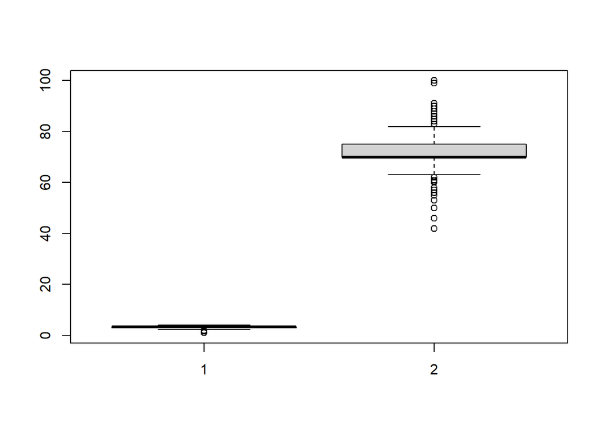

```r
boxplot(choco$Rating, choco$Cocoa_Percent)
```

4. How do different bean origins compare in terms of the flavor of chocolates? Are beans from some places better than the other? Create both numerical and graphical summaries, and explain.

```r
origins <- table(choco$Bean_Origin)
str(origins)
```

```
##  'table' int [1:63(1d)] 3 67 1 151 72 1 75 1 3 66 ...
##  - attr(*, "dimnames")=List of 1
##   ..$ : chr [1:63] "Australia" "Belize" "blend" "Blend" ...
```

```r
origins5 <- head(sort(origins,decreasing=TRUE),n=5)
names(origins5)
```

```
## [1] "Venezuela"          "Peru"               "Ecuador"
## [4] "Dominican Republic" "Madagascar"
```

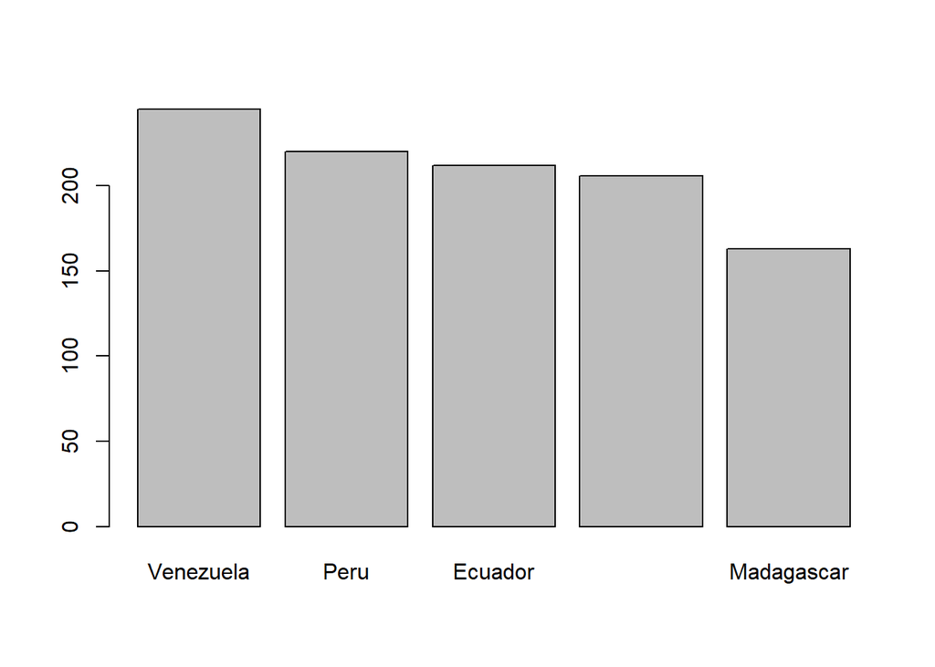

```r
barplot(origins5)
```

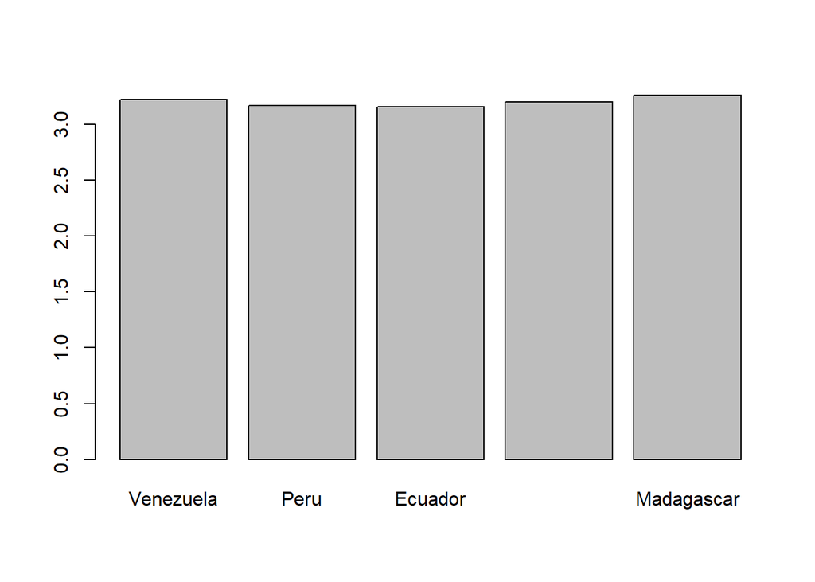

```r
venezuela <- choco[choco$Bean_Origin == 'Venezuela',]
peru <- choco[choco$Bean_Origin == 'Peru',]
ecuador <- choco[choco$Bean_Origin == 'Ecuador',]
dominican <- choco[choco$Bean_Origin == 'Dominican Republic',]
madagascar <- choco[choco$Bean_Origin == 'Madagascar',]
vrating <- venezuela$Rating
prating <- peru$Rating
erating <- ecuador$Rating
drating <- dominican$Rating
mrating <- madagascar$Rating
vave <- mean(vrating)
pave <- mean(prating)
eave <- mean(erating)
dave <- mean(drating)
mave <- mean(mrating)
averating <- c(vave, pave, eave, dave, mave)
names(averating) <- c('Venezuela','Peru','Ecuador','Dominican Republic','Madagascar')
barplot(averating)
```

```r
averating
```

```
##          Venezuela               Peru            Ecuador Dominican Republic
##           3.224490           3.165909           3.159198           3.201942
##         Madagascar
##           3.260736
```

From the first graphical bar plot you can see that the top 5 bean origins are from Venezuela, Peru, Ecuador, Dominican Republic and Madagascar. From the second graphical and numerical summaries one can see that from the top 5 bean origin countries all 5 countries have relatively close chocolate rating averages. Therefore, bean origins do not have an affect in terms of the flavor of chocolates.

5. Brainstorm two analyses you would like to perform (with your teammates). Describe in plain language what comparisons are you making. Create suitable numerical and graphical summaries for your analyses. Describe the results.

Our first analysis will be to determine if the companies have any affect on rating. Our plan is to first extract the top 5 companies that have the most amount of entries in the data set. Then we will extract the rating data of these 5 companies from the data set. After that, we will create a bar graph and print the average ratings.

```r
companies <- table(choco$Company)
str(companies)
```

```
##  'table' int [1:541(1d)] 3 25 4 4 4 2 1 3 6 4 ...
##  - attr(*, "dimnames")=List of 1
##   ..$ : chr [1:541] "5150" "A. Morin" "Acalli" "Adi aka Fijiana (Easy In Ltd)" ...
```

```r
companies5 <- head(sort(companies,decreasing=TRUE),n=5)
names(companies5)
```

```
## [1] "Soma"   "Arete"  "Fresco" "Bonnat" "Pralus"
```

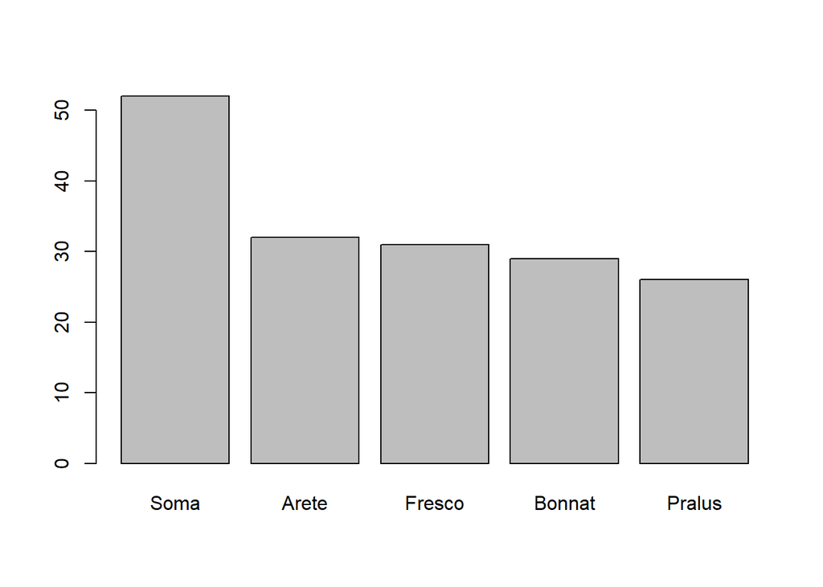

```r
barplot(companies5)
```

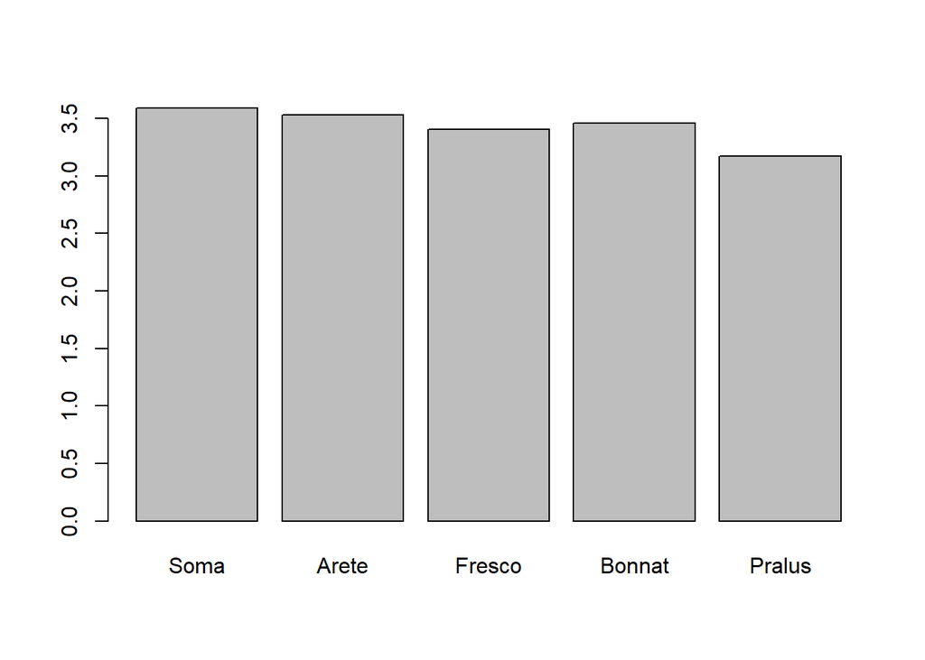

```r
soma <- choco[choco$Company == 'Soma',]
arete <- choco[choco$Company == 'Arete',]
fresco <- choco[choco$Company == 'Fresco',]
bonnat <- choco[choco$Company == 'Bonnat',]
pralus <- choco[choco$Company == 'Pralus',]
srating <- soma$Rating
arating <- arete$Rating
frating <- fresco$Rating
brating <- bonnat$Rating
prating <- pralus$Rating
save <- mean(srating)
aave <- mean(arating)
fave <- mean(frating)
bave <- mean(brating)
pave <- mean(prating)
averating1 <- c(save, aave, fave, bave, pave)
names(averating1) <- c('Soma','Arete','Fresco','Bonnat','Pralus')
barplot(averating1)
```

```r
averating1
```

```
##     Soma    Arete   Fresco   Bonnat   Pralus
## 3.591346 3.531250 3.403226 3.456897 3.173077
```

The top 5 chocolate companies shown in the graphical bar plot include Soma, Arete, Fresco, Bonnat and Pralus. We can also see from the bar plot that Soma is almost twice the size of the remaining top 4 companies for chocolate. Continuing on with the analysis, we can see from the second bar plot and numerical list that the average ratings for the top 5 companies are quite similar, but there is a slight range with Soma at 3.59 to Pralus at a 3.17. Thus being said, Chocolate Companies only have a slight affect in terms of comparison to the chocolate ratings.

```r
dates <- table(choco$Date)
str(dates)
```

```
##  'table' int [1:15(1d)] 62 73 92 123 110 163 194 184 247 284 ...
##  - attr(*, "dimnames")=List of 1
##   ..$ : chr [1:15] "2006" "2007" "2008" "2009" ...
```

```r
dates5 <- head(sort(dates,decreasing=TRUE),n=5)
names(dates5)
```

```
## [1] "2015" "2014" "2018" "2016" "2019"
```

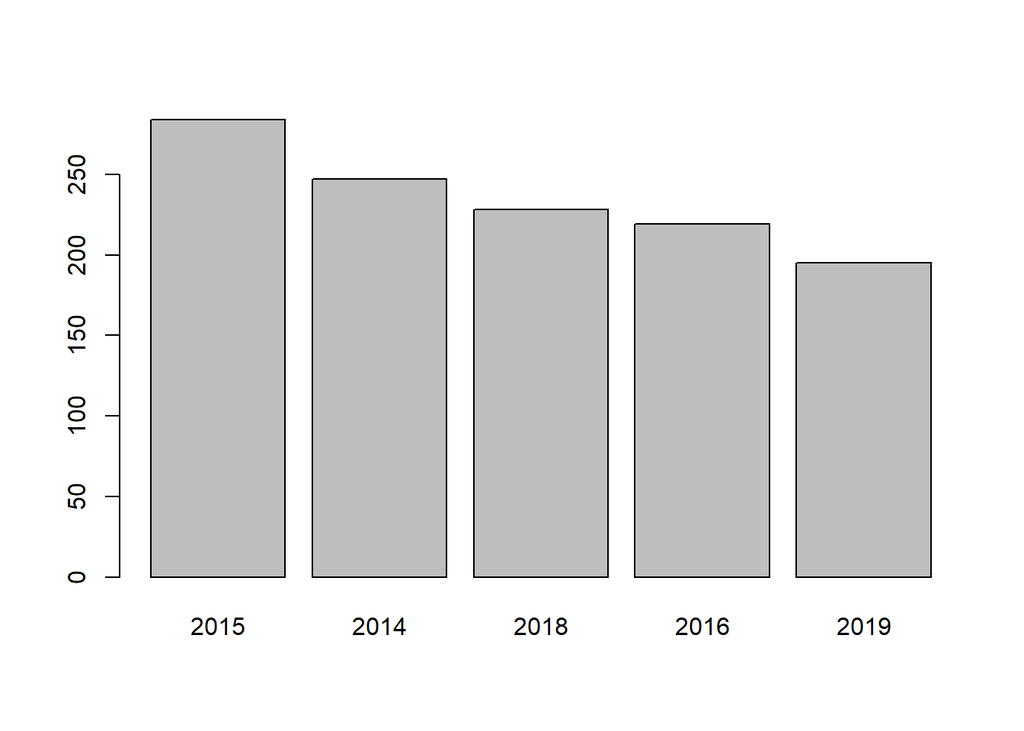

```r
barplot(dates5)
```

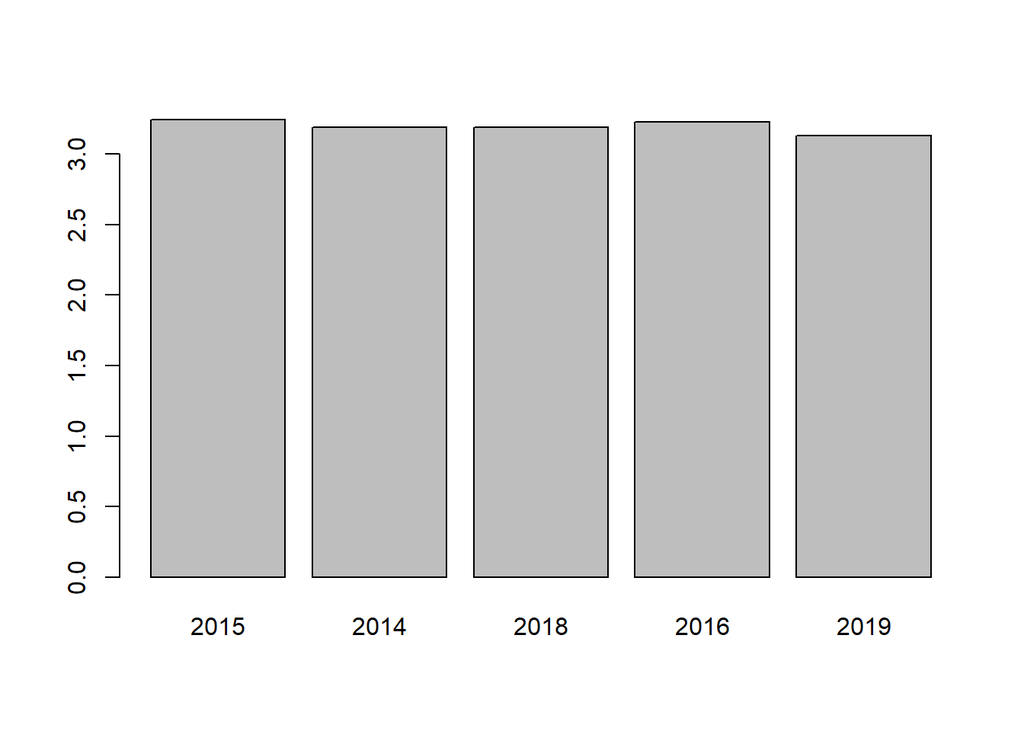

```r
five <- choco[choco$Date == '2015',]
four <- choco[choco$Date == '2014',]
eight <- choco[choco$Date == '2018',]
six <- choco[choco$Date == '2016',]
nine <- choco[choco$Date == '2019',]
fiverating <- five$Rating
fourrating <- four$Rating
eightrating <- eight$Rating
sixrating <- six$Rating
ninerating <- nine$Rating
fiveave <- mean(fiverating)
fourave <- mean(fourrating)
eightave <- mean(eightrating)
sixave <- mean(sixrating)
nineave <- mean(ninerating)
averating2 <- c(fiveave, fourave, eightave, sixave, nineave)
names(averating2) <- c('2015','2014','2018','2016','2019')
barplot(averating2)
```

```r
averating2
```

```
##     2015     2014     2018     2016     2019
## 3.244718 3.189271 3.192325 3.226027 3.133333
```

The top 5 years shown in the graphical bar plot include 2015, 2014, 2018, 2016 and 2019. We can also see from the bar plot that 2015 was the year with the most entries from the data set. Continuing on with the analysis, we can see from the second bar plot and numerical list that the average ratings for the top 5 years are very similar meaning that the years/date do not have an affect on the chocolate ratings.